[figure not shown]

# Machine Learning Programming Workshop

## 1.2 Intuition for Machine Learning (Part 1)

#### Prepared By: [Cheong Shiu Hong (FTFNCE)](https://www.linkedin.com/in/cheongshiuhong/)

## Contents

- 1) Vectors
  - 1.0 Quick Introduction/Refresher on NumPy
  - 1.1 Scalar Operations on Vectors
  - 1.2 Element-Wise Operations of Vectors
  - 1.2 Dot Product of Vectors
- 2) Matrices
  - 2.1 Scalar Operations on Matrices
  - 2.2 Element-Wise Operations of Matrices
  - 2.3 Dot Product of Matrices
  - 2.4 Row Vectors vs Column Vectors
- Practice Questions
- Example 1
- Example 2
- Example 3

```python
import numpy as np
import pandas as pd
import matplotlib.pyplot as plt
```

# Linear Algebra

### What is Linear Algebra?

#### For us, Linear Algebra will only be the use of Vectors and Matrices to represent Data

# 1) Vectors

return to top

### Think of Vectors as storing values in a list

#### 2 Item Vector

$ \vec{a} = \left[ {\begin{array}{c} 1 \\ 2\end{array} } \right] $

#### 5 Item Vector

$ \vec{a} = \left[ {\begin{array}{c} 1 \\ 2 \\ 3 \\ 4 \\ 5\end{array} } \right] $

## 1.0 Quick Introduction/Refresher on NumPy

return to top

#### This is a normal Python List:

```python
a_list = [1, 2, 3] # This is a Python List
```

#### We can create a NumPy Array using numpy.array() <-- where the input is a list

```python
a = np.array(a_list) # This is a NumPy Array with a Python List as the Input
```

```python
b = np.array([1, 2, 3]) # We can directly put the list as the input as well
```

#### Notice that when we print a NumPy array, it does not show the comma seperators, as compared to a list

```python
# Print Python List
print(a_list)
```

```
[1, 2, 3]
```

```python
# Print NumPy Array
print(a)
```

```
[1 2 3]
```

```python
# Print NumPy Array
print(b)
```

```
[1 2 3]
```

#### And when we are too lazy to print them, the outputs look different

```python
a_list # Looks exactly the same as when we printed the Python List
```

```
[1, 2, 3]
```

```python
a # Wrapped with "array()"
```

```
array([1, 2, 3])
```

#### Python Lists are not suitable for Numerical Operations as shown here:

```python
# Python List Multiplied
a_list * 2
```

```
[1, 2, 3, 1, 2, 3]
```

```python
a_list + 2
```

```
---------------------------------------------------------------------------
TypeError                                 Traceback (most recent call last)
<ipython-input-11-02b9e2681e45> in <module>
----> 1 a_list + 2

TypeError: can only concatenate list (not "int") to list
```

#### Arange Function

```python
x = np.arange(start=0, stop=10, step=2)
print(x)
```

```
[0 2 4 6 8]
```

#### Linspace Function

```python
x = np.linspace(start=0, stop=10, num=5)
print(x)
```

```
[ 0.   2.5  5.   7.5 10. ]
```

#### Random Numbers (Useful for Monte-Carlo Simulations)

```python
random_number = np.random.normal(loc=10, scale=5) # Mean = 10, Std = 5
print(random_number)
```

```
11.317773962493996
```

```python
random_numbers = np.random.normal(loc=10, scale=5, size=(3,2))
print(random_numbers)
```

```
[[10.59898706 16.43157534]
 [10.46388898  9.96613283]
 [17.45742108 13.22887167]]
```

```python
random_numbers = np.random.randn(3, 2) # Shape of Matrix (Array) Generated from the Standard Normal Distribution
print(random_numbers)
```

```
[[-0.1626074   0.31855505]
 [-1.6269628  -1.09416509]
 [ 0.35545624  1.12959288]]
```

```python
random_numbers = 10 + np.random.randn(3, 2) * 5 # Manually Shifting the Mean, and Scaling the Standard Deviation
print(random_numbers)
```

```
[[ 2.13292476  8.92026878]
 [14.579544   15.42312814]
 [12.7183639  10.50124078]]
```

#### Manually Shifting and Scaling Distributions for each Column

```python
random_numbers = np.random.randn(3,2)
random_numbers[:,0] = 10 + random_numbers[:,0] * 5 # First Column with Mean = 10, Std = 5
random_numbers[:,1] = 50 + random_numbers[:,1] * 10 # Second Column with Mean = 50, Std = 10
print(random_numbers)
```

```
[[11.50909305 49.95876646]
 [16.39788216 47.6661138 ]
 [15.95814151 59.84214946]]
```

#### Normal Distribution

```python
x = 10 + np.random.randn(10000) * 10 # Generate 1000 Normally Distribued Numbers in an Array

print('Mean: {:.2f} | Standard Deviation: {:.2f}'.format(x.mean(), x.std())) # Verify the Mean and Standard Deviation
```

```
Mean: 10.05 | Standard Deviation: 10.07
```

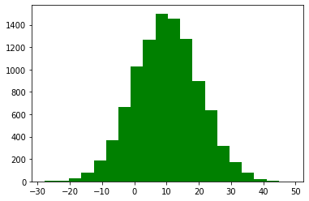

```python
plt.hist(x, bins=20, color='green')
plt.show();
```

#### Uniform Distribution

```python
x = np.random.uniform(low=10, high=20, size=10000) # Generate 1000 Uniformly Distributed Numbers in an Array

print('Mean: {:.2f} | Standard Deviation: {:.2f}'.format(x.mean(), x.std())) # Verify the Mean and Standard Deviation
```

```
Mean: 15.02 | Standard Deviation: 2.89
```

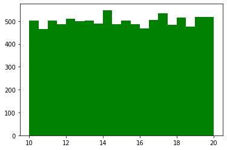

```python
plt.hist(x, bins=20, color='green')
plt.show();
```

#### Transpose Method

```python
print(random_numbers) # 3x2 Matrix
```

```
[[11.50909305 49.95876646]
 [16.39788216 47.6661138 ]
 [15.95814151 59.84214946]]
```

```python
print(random_numbers.T) # 2x3 Matrix
```

```
[[11.50909305 16.39788216 15.95814151]
 [49.95876646 47.6661138  59.84214946]]
```

## 1.1 Scalar Operations on Vectors

return to top

#### Let's think of Vector $\vec{a}$ as Tom having 1 Apple and Harry having 2 Apples.

### Vector $\vec{a}$

$ \vec{a} = \left[ {\begin{array}{c} 1 \\ 2\end{array} } \right] $

```python
a = np.array([1, 2])
```

### Addition

#### If I gave both Tom and Harry 2 Apples:

### $ 2 + \vec{a}$

$= 2 + \left[ {\begin{array}{c} 1 \\ 2\end{array} } \right]$

$= \left[ {\begin{array}{c} 3 \\ 4\end{array} } \right]$

```python
2 + a
```

```
array([3, 4])
```

### Multiplication

#### If both Tom and Harry Doubled their Apples:

### $ 2 \times \vec{a}$

$= 2 \times \left[ {\begin{array}{c} 1 \\ 2\end{array} } \right]$

$= \left[ {\begin{array}{c} 2 \\ 4\end{array} } \right]$

```python
2 * a
```

```
array([2, 4])
```

#### Notice that for Scalar Operations, order does NOT Matter

```python
a + 2
```

```
array([3, 4])
```

```python
a * 2
```

```
array([2, 4])
```

## 1.2 Element-Wise Operations of Vectors

return to top

#### Let's think of Vector $\vec{a}$ as Tom earning 1 Dollar/Day and Harry earning 2 Dollars/Day.

### Vector $\vec{a}$ and Vector $\vec{b}$

$ \vec{a} = \left[ {\begin{array}{c} 1 \\ 2\end{array} } \right] $

$ \vec{b} = \left[ {\begin{array}{c} 5 \\ 6\end{array} } \right] $

```python
a = np.array([1, 2])
b = np.array([5, 6])
```

### Addition

#### If I gave Tom 5 Dollars and Harry 6 Dollars:

### $\vec{a} + \vec{b}$

$= \left[ {\begin{array}{c} 1 \\ 2\end{array} } \right] + \left[ {\begin{array}{c} 5 \\ 6\end{array} } \right]$

$= \left[ {\begin{array}{c} 6 \\ 8\end{array} } \right] $

```python
a + b
```

```
array([6, 8])
```

### Multiplication

#### If Tom works 5 Days a Week and Harry Works 6 Days a Week:

### $\vec{a} \times \vec{b}$

$= \left[ {\begin{array}{c} 1 \\ 2\end{array} } \right] \times \left[ {\begin{array}{c} 5 \\ 6\end{array} } \right]$  
$= \left[ {\begin{array}{c} 5 \\ 12\end{array} } \right] $

```python
a * b
```

```
array([ 5, 12])
```

#### Notice that for Element-Wise Operations, order does NOT Matter also

```python
b + a
```

```
array([6, 8])
```

```python
b * a
```

```
array([ 5, 12])
```

## 1.3 Dot Product of Vectors

return to top

#### For Vectors, the Dot Product is pretty much Multiplying each Pair and summing the Product Together

#### How Much Money will Both Tom and Harry have after the week?

### $\vec{a} . \vec{b}$

$= \left[ {\begin{array}{c} 1 \\ 2\end{array} } \right] . \left[ {\begin{array}{c} 5 \\ 6\end{array} } \right]$

$= (1 \times 5) + (2 \times 6)$

$= 5 + 12$

$= 17$

```python
np.dot(a, b)
```

```
17
```

#### More formally, the Dot Product is the product of the length of a Vector multiplied by the length of the other Vector projected onto itself.

#### $\vec{a}.\vec{b}$ = $||\vec{a}||$ . $||\vec{b}||$ . $cos(\theta)$, where $|\vec{a}|$ is the size (length) of $\vec{a}$ and $\theta$ is the angle between $\vec{a}$ and $\vec{b}$.

*Fun Fact: The Dot Product of a Vector with itself is pretty much the squared size (length) of the Vector, since:*  
$\theta = 0$ (Angle between a Vector and itself is $0^o$) cos$(\theta) = 1$ (Cosine of 0 is 1) $\therefore \vec{a}.\vec{a}$ $= ||\vec{a}|| . ||\vec{a}|| . cos(\theta)$ $= ||\vec{a}|| . ||\vec{a}||$ $= ||\vec{a}||^2$

#### With the same logic, if two Vectors are Orthogonal ($90^o$ from each other), the Dot Product will be 0, since cos(90) = 0 And for Vectors Pointing in the Opposite Direction, the Dot Product will be Negative since cos$(\theta)$ < 0 for ($90^o$ < $\theta$ <= $180^o$)

[Click here if you're interested to learn more](https://en.wikipedia.org/wiki/Dot_product)

# 2) Matrices

return to top

### Think of Matrices as Multiple Vectors in another Vector

```python
A = np.array([[1,2,3],
              [4,5,6]])

B = np.array([[9,8,7,6],
              [8,7,6,5],
              [7,6,5,4]])
```

```python
print('Shape of A:\n', A.shape)
print('Shape of B:\n', B.shape)
```

```
Shape of A:
 (2, 3)
Shape of B:
 (3, 4)
```

## 2.1 Scalar Operations on Matrices

return to top

```python
A
```

```
array([[1, 2, 3],
       [4, 5, 6]])
```

### Adding/Multiplying a Number with Matrices

#### Scalar will be broadcasted and operated on every value in the Matrix

```python
10 + A
```

```
array([[11, 12, 13],
       [14, 15, 16]])
```

```python
10 * A
```

```
array([[10, 20, 30],
       [40, 50, 60]])
```

## 2.2 Element-Wise Operations of Matrices

return to top

```python
A
```

```
array([[1, 2, 3],
       [4, 5, 6]])
```

```python
B
```

```
array([[9, 8, 7, 6],
       [8, 7, 6, 5],
       [7, 6, 5, 4]])
```

### Adding/Multiplying Different Shaped Matrices Together?

```python
A + B
```

```
---------------------------------------------------------------------------
ValueError                                Traceback (most recent call last)
<ipython-input-43-151064de832d> in <module>
----> 1 A + B

ValueError: operands could not be broadcast together with shapes (2,3) (3,4)
```

```python
B + A
```

```
---------------------------------------------------------------------------
ValueError                                Traceback (most recent call last)
<ipython-input-44-b1a194f9b6dc> in <module>
----> 1 B + A

ValueError: operands could not be broadcast together with shapes (3,4) (2,3)
```

```python
A * B
```

```
---------------------------------------------------------------------------
ValueError                                Traceback (most recent call last)
<ipython-input-45-a4cedde81ed0> in <module>
----> 1 A * B

ValueError: operands could not be broadcast together with shapes (2,3) (3,4)
```

```python
B * A
```

```
---------------------------------------------------------------------------
ValueError                                Traceback (most recent call last)
<ipython-input-46-36ca14b77ca1> in <module>
----> 1 B * A

ValueError: operands could not be broadcast together with shapes (3,4) (2,3)
```

### NOTE: Matrices have to be of the SAME SHAPE for Element-Wise Operations!

```python
A + A
```

```
array([[ 2,  4,  6],
       [ 8, 10, 12]])
```

```python
B + B
```

```
array([[18, 16, 14, 12],
       [16, 14, 12, 10],
       [14, 12, 10,  8]])
```

```python
A * A
```

```
array([[ 1,  4,  9],
       [16, 25, 36]])
```

```python
B * B
```

```
array([[81, 64, 49, 36],
       [64, 49, 36, 25],
       [49, 36, 25, 16]])
```

## 2.3 Dot Product of Matrices

return to top

### Intuition Behind the Operation:

#### There are 2 Fruit Stalls, each selling fruits at different prices:

$A = \left[ {\begin{array}{c} 1 & 2 & 3 \\ 4 & 5 & 6\end{array} } \right]$

#### The number of Days of Data recorded is 4 (A.K.A 4 Samples)

#### E.g. I bought 9 Apples, 8 Bananas, 7 Carrots on Day 1, and I bought 8 Apples, 7 Bananas, 6 Carrots on Day 2...

$B = \left[ {\begin{array}{c} 9 & 8 & 7 & 6 \\ 8 & 7 & 6 & 5 \\ 7 & 6 & 5 & 4\end{array} } \right]$

### Taking the Dot Product of (2 Stalls x 3 Fruits) and (3 Fruits x 4 Days) can be interpreted as:

#### Finding the amount spent at Each Stall, on Each Day. Output: (2 Stalls, 4 Days) Notice (3 Fruits) is not in the Output, as that is our "Inner Dimension" or the Dimension that we are Summing over.

$A.B = \left[ {\begin{array}{c} 1 & 2 & 3 \\ 4 & 5 & 6\end{array} } \right] . \left[ {\begin{array}{c} 9 & 8 & 7 & 6 \\ 8 & 7 & 6 & 5 \\ 7 & 6 & 5 & 4\end{array} } \right]$

$= \left[ {\begin{array}{c} (1 \times 9) + (2 \times 8) + (3 \times 7) & ... \\ (4 \times 9) + (5 \times 8) + (6 \times 7) & ...\end{array} } \right]$

$= \left[ {\begin{array}{c} 46 & 40 & 34 & 28 \\ 118 & 103 & 88 & 73 \end{array} } \right]$

### We can only take the Dot Product of a (M x N) matrix, with a (N x O) matrix, where the Inner Dimensions Match

### $\mathbb{R}^{M \times N} . \mathbb{R}^{N \times O} = \mathbb{R}^{M \times O}$

#### Dot Product of (M x N) matrix and (N x O) matrix gives us (M x O) Matrix

```python
print('Matrix A:'); print(A); print('Shape:', A.shape)
```

```
Matrix A:
[[1 2 3]
 [4 5 6]]
Shape: (2, 3)
```

```python
print('Matrix B:'); print(B); print('Shape:', B.shape)
```

```
Matrix B:
[[9 8 7 6]
 [8 7 6 5]
 [7 6 5 4]]
Shape: (3, 4)
```

#### Dot Product of (2 x 3) Matrix and (3 x 4) Matrix gives us (2 x 4) Matrix

```python
np.dot(A, B)
```

```
array([[ 46,  40,  34,  28],
       [118, 103,  88,  73]])
```

```python
np.dot(A, B).shape
```

```
(2, 4)
```

### $\mathbb{R}^{N \times O} . \mathbb{R}^{M \times N} = ERROR$

#### Dot Product of (N x O) matrix and (M x N) matrix gives us Error!

Inner Dimensions Do Not Match!

```python
np.dot(B, A)
```

```
---------------------------------------------------------------------------
ValueError                                Traceback (most recent call last)
<ipython-input-55-831079463ca7> in <module>
----> 1 np.dot(B, A)

ValueError: shapes (3,4) and (2,3) not aligned: 4 (dim 1) != 2 (dim 0)
```

## 2.4 Row Vectors vs Column Vectors

return to top

### Which is a Row Vector and which is a Column Vector?

$\vec{a} = \left[ {\begin{array}{c} 1 & 2\end{array} } \right]$

$\vec{b} = \left[ {\begin{array}{c} 5 \\ 6\end{array} } \right]$

```python
a = np.array([1,2])

b = np.array([5,
              6])

print('Vector a:\n', a)
print('Vector b:\n', b)
```

```
Vector a:
 [1 2]
Vector b:
 [5 6]
```

```python
print('Shape of a:\n', a.shape)
print('Shape of b:\n', b.shape)
```

```
Shape of a:
 (2,)
Shape of b:
 (2,)
```

### How do we Differentiate between a Row Vector vs a Column Vector in NumPy?

$\vec{a} = \left[ {\begin{array}{c} 1 & 2\end{array} } \right]$

$\vec{b} = \left[ {\begin{array}{c} 5 \\ 6\end{array} } \right]$

#### Think of Row Vectors as a 1-Row, N-Column Matrix (1 x N)

#### Think of Column Vectors as a N-Row, 1-Column Matrix (N x 1)

```python
a = np.array([[1, 2]])

b = np.array([[5],
              [6]])

print('Vector a:\n', a)
print('Vector b:\n', b)
```

```
Vector a:
 [[1 2]]
Vector b:
 [[5]
 [6]]
```

```python
print('Shape of a:\n', a.shape)
print('Shape of b:\n', b.shape)
```

```
Shape of a:
 (1, 2)
Shape of b:
 (2, 1)
```

### Dot Product of Row Vector with Column Vector

$\left[ {\begin{array}{c} 1 & 2\end{array} } \right] . \left[ {\begin{array}{c} 5 \\ 6\end{array} } \right]$

```python
np.dot(a, b)
```

```
array([[17]])
```

### Dot Product of Column Vector with Row Vector

$\left[ {\begin{array}{c} 5 \\ 6\end{array} } \right] . \left[ {\begin{array}{c} 1 & 2\end{array} } \right]$

```python
np.dot(b, a)
```

```
array([[ 5, 10],
       [ 6, 12]])
```

# Practice Questions:

return to top

## Let's Try Some Practice Questions:

### Question 1

#### Calculate the Following:

$3 \times \left[ {\begin{array}{c} 2 & 7 \\ 1 & 5\end{array} } \right]$

### Question 2

#### Calculate the Dot Product of the Following:

$\left[ {\begin{array}{c} 4 & 3\end{array} } \right] . \left[ {\begin{array}{c} 2 \\ 5\end{array} } \right]$

### Question 3

#### Calculate the Dot Product of the Following:

$\left[ {\begin{array}{c} 2 & 6 & -1 \\ -3 & 4 & 3 \end{array} } \right] . \left[ {\begin{array}{c} 2 & 4 \\ 5 & -2 \\ 3 & -1 \end{array} } \right]$

### Question 4

#### Calculate the Dot Product of the Following:

$\left[ {\begin{array}{c} 2 & 6 & -1 & 5 & 7\\ -3 & 4 & 3 & 2 & -7 \\ -1 & 2 & -2 & -5 & 4 \\ 3 & 2 & 8 & -4 & 3\end{array} } \right] . \left[ {\begin{array}{c} 2 & 4 & 5\\ 5 & -2 & 1 \\ 3 & -1 & -7 \\ -2 & -4 & -4 \\ 4 & 6 & 1 \end{array} } \right]$

#### JK. We should use NumPy for this:

```python
a = np.array([[ 2, 6, -1,  5,  7],
              [-3, 4,  3,  2, -7],
              [-1, 2, -2, -5,  4],
              [ 3, 2,  8, -4,  3]])

b = np.array([[ 2,  4,  5],
              [ 5, -2,  1],
              [ 3, -1, -7],
              [-2, -4, -4],
              [ 4,  6,  1]])

np.dot(a, b)
```

```
array([[ 49,  19,  10],
       [ -9, -73, -47],
       [ 28,  38,  35],
       [ 60,  34, -20]])
```

#### Notice that when we (Humans) vectorize information, we calculate each item sequentially, so it seems like there are no benefits to this

### However, computers benefit greatly from vectorization:

```python
# Create 1,000,000 Sized Arrays
a = np.random.randn(1000000)
b = np.random.randn(1000000)

print(a.shape, b.shape)
```

```
(1000000,) (1000000,)
```

```python
%%time

# Explicit For Loops
c = 0
for i in range(len(a)):
    c += a[i] * b[i]
print(c)
```

```
-738.5690346418623
Wall time: 506 ms
```

```python
%%time

# Element-Wise Multiplication, then Summing them together
c = sum(a * b)
print(c)
```

```
-738.5690346418623
Wall time: 165 ms
```

```python
%%time

# Matrix Multiplication
c = a @ b
print(c)
```

```
-738.5690346418631
Wall time: 0 ns
```

```python
%%time

# Dot Product
c = np.dot(a, b)
print(c)
```

```
-738.5690346418631
Wall time: 1.01 ms
```

#### In fact it can be ~1000x Faster when dealing with Larger Arrays as seen in the 100,000,000 sized calculations below

#### Also, when we utilize Machine Learning Libraries like PyTorch and Tensorflow that utilizes GPU power, 43s can become 4ms

### PyTorch

[figure not shown]

The GPU with PyTorch was done on a Desktop Computer with an nVidia GPU (We won't be able to do that with Laptop Integrated Graphics unless you're a hardcore gamer and you have your dedicated graphics properly set up).

Or, we could use Cloud Computing Services).

# Example 1:

return to top

### 2 Apples + 1 Banana will Cost $13

### 3 Apples + 2 Banana will Cost $22

### Vectorize the Information as:

$\left[ {\begin{array}{c} 2 & 1 \\ 3 & 2\end{array} } \right] . \left[ {\begin{array}{c} A \\ B\end{array} } \right] = \left[ {\begin{array}{c} 13 \\ 22\end{array} } \right]$

### Dot Product would give us:

$\left[ {\begin{array}{c} 2A + 1B \\ 3A + 2B\end{array} } \right] = \left[ {\begin{array}{c} 13 \\ 22\end{array} } \right]$

### Think of Rows as Samples, Columns as Variables for Each Item {A, B}

Solving {A, B} is not the Point here, the Representation of Data by Vectorization is the Point.

### A = 4

### B = 5

#### Solving with Linear Algebra

```python
units = np.array([[2,1], [3,2]])
cost = np.array([13,22])
```

```python
np.linalg.inv(units) @ cost
```

```
array([4., 5.])
```

# Example 2:

return to top

### 2 Apples + 1 Banana will Cost $12

### 3 Apples + 2 Banana will Cost $19

### New Variable: Ordering Cost of $O/Purchase

### Vectorize the Information as:

$\left[ {\begin{array}{c} 2 & 1 \\ 3 & 2\end{array} } \right] . \left[ {\begin{array}{c} A \\ B\end{array} } \right] + O = \left[ {\begin{array}{c} 12 \\ 19\end{array} } \right]$

### Dot Product would give us:

$\left[ {\begin{array}{c} 2A + 1B \\ 3A + 2B\end{array} } \right] + O = \left[ {\begin{array}{c} 12 \\ 19\end{array} } \right]$

### Broadcast O:

$\left[ {\begin{array}{c} 2A + 1B + O\\ 3A + 2B + O\end{array} } \right] = \left[ {\begin{array}{c} 12 \\ 19\end{array} } \right]$

### Think of Rows as Samples, Columns as Variables for Each Item {A, B}

Again, Solving {A, B, O} is not the Point here, the Representation of Data by Vectorization is the Point.

### A = 3

### B = 4

### O = 2

### Note that we can always re-write as:

$\left[ {\begin{array}{c} 2 & 1\\ 3 & 2\end{array} } \right] . \left[ {\begin{array}{c} A \\ B\end{array} } \right] = \left[ {\begin{array}{c} 12-O \\ 19-O\end{array} } \right]$

or

$\left[ {\begin{array}{c} 2 & 1 & 1\\ 3 & 2 & 1\end{array} } \right] . \left[ {\begin{array}{c} A \\ B\\ O \end{array} } \right] = \left[ {\begin{array}{c} 12 \\ 19\end{array} } \right]$

# Example 3:

return to top

### 2 Apples + 1 Banana will Cost $13

### 3 Apples + 2 Banana will Cost $18

### New Variable: Ordering Cost of $2/Purchase

### O = 2

### Vectorize the Information as:

$\left[ {\begin{array}{c} 2 & 1 \\ 3 & 2\end{array} } \right] . \left[ {\begin{array}{c} A \\ B\end{array} } \right] + 2 = \left[ {\begin{array}{c} 13 \\ 18\end{array} } \right]$

### Dot Product would give us:

$\left[ {\begin{array}{c} 2A + 1B \\ 3A + 2B\end{array} } \right] + 2 = \left[ {\begin{array}{c} 13 \\ 18\end{array} } \right]$

### Broadcast 2:

$\left[ {\begin{array}{c} 2A + 1B + 2\\ 3A + 2B + 2\end{array} } \right] = \left[ {\begin{array}{c} 13 \\ 18\end{array} } \right]$

### Now we shift our focus to Finding the Best Estimate of A and B, to minimize the Error in Predicted Cost

#### For Instance:

### A = 3

### B = 4

$Predicted = \left[ {\begin{array}{c} 2 & 1 \\ 3 & 2\end{array} } \right] . \left[ {\begin{array}{c} 3 \\ 4\end{array} } \right] + 2$

$= \left[ {\begin{array}{c} 2\times3 + 1\times4 \\ 3\times3 + 2\times4\end{array} } \right] + 2$

$= \left[ {\begin{array}{c} 6 + 4\\ 9 + 8\end{array} } \right] + 2$

$= \left[ {\begin{array}{c} 10\\ 17\end{array} } \right] + 2$

$= \left[ {\begin{array}{c} 12 \\ 19\end{array} } \right]$

$Error = Prediction - Actual$

$Error = \left[ {\begin{array}{c} 12 \\ 19\end{array} } \right] - \left[ {\begin{array}{c} 13 \\ 18\end{array} } \right]$

$= \left[ {\begin{array}{c} -1 \\ 1\end{array} } \right]$

### Are there better answers?

### To see how we can minimize Error, we will look into Differentiation in the Part 2.

### Demonstration of the Use of Linear Algebra in Machine Learning / Data Analysis

```python
prices = pd.read_csv('./sources/prices.csv', index_col=0)
```

```python
prices.head()
```

| Date | ^DJI | ^GSPC | ^IXIC | ^N225 | ^STI | ^FTSE |
| --- | --- | --- | --- | --- | --- | --- |
| 1988-01-05 | 2031.500000 | 258.630005 | 344.100006 | 21575.279297 | 879.299988 | 1789.599976 |
| 1988-01-06 | 2037.800049 | 258.890015 | 346.700012 | 22790.500000 | 906.000000 | 1787.099976 |
| 1988-01-07 | 2051.889893 | 261.070007 | 349.700012 | 22792.130859 | 911.500000 | 1787.199951 |
| 1988-01-11 | 1945.130005 | 247.490005 | 336.200012 | 22578.429688 | 849.099976 | 1760.199951 |
| 1988-01-12 | 1928.550049 | 245.419998 | 332.000000 | 22625.050781 | 870.500000 | 1739.199951 |

```python
returns = prices.pct_change().dropna()
```

```python
returns.head()
```

| Date | ^DJI | ^GSPC | ^IXIC | ^N225 | ^STI | ^FTSE |
| --- | --- | --- | --- | --- | --- | --- |
| 1988-01-06 | 0.003101 | 0.001005 | 0.007556 | 0.056325 | 0.030365 | -0.001397 |
| 1988-01-07 | 0.006914 | 0.008421 | 0.008653 | 0.000072 | 0.006071 | 0.000056 |
| 1988-01-11 | -0.052030 | -0.052017 | -0.038605 | -0.009376 | -0.068459 | -0.015107 |
| 1988-01-12 | -0.008524 | -0.008364 | -0.012493 | 0.002065 | 0.025203 | -0.011930 |
| 1988-01-13 | -0.001981 | 0.001589 | 0.002108 | -0.013262 | -0.019069 | -0.003335 |

```python
returns.describe()
```

|  | ^DJI | ^GSPC | ^IXIC | ^N225 | ^STI | ^FTSE |
| --- | --- | --- | --- | --- | --- | --- |
| count | 5696.000000 | 5696.000000 | 5696.000000 | 5696.000000 | 5696.000000 | 5696.000000 |
| mean | 0.000534 | 0.000517 | 0.000696 | 0.000146 | 0.000330 | 0.000326 |
| std | 0.012212 | 0.012676 | 0.016322 | 0.016415 | 0.014444 | 0.012733 |
| min | -0.083504 | -0.090350 | -0.111869 | -0.115083 | -0.143733 | -0.097180 |
| 25% | -0.004861 | -0.004930 | -0.006482 | -0.008044 | -0.005957 | -0.005836 |
| 50% | 0.000718 | 0.000750 | 0.001299 | 0.000401 | 0.000214 | 0.000568 |
| 75% | 0.006316 | 0.006371 | 0.008246 | 0.008887 | 0.006512 | 0.006594 |
| max | 0.111719 | 0.109862 | 0.174129 | 0.141503 | 0.165564 | 0.117520 |

#### Principal Component Analysis

```python
corr_matrix = returns.corr()
print(corr_matrix)
```

```
           ^DJI     ^GSPC     ^IXIC     ^N225      ^STI     ^FTSE
^DJI   1.000000  0.961414  0.778719  0.240502  0.312357  0.568400
^GSPC  0.961414  1.000000  0.865143  0.247373  0.313128  0.581679
^IXIC  0.778719  0.865143  1.000000  0.231036  0.299734  0.503981
^N225  0.240502  0.247373  0.231036  1.000000  0.454051  0.365782
^STI   0.312357  0.313128  0.299734  0.454051  1.000000  0.425637
^FTSE  0.568400  0.581679  0.503981  0.365782  0.425637  1.000000
```

```python
eigvals, eigvecs = np.linalg.eig(corr_matrix) # Eigen-decomposition of the Correlation Matrix
```

```python
idx = np.argsort(eigvals)[::-1]
eigvals = eigvals[idx]
eigvecs = eigvecs[:, idx]
var_contri = eigvals / eigvals.sum()
```

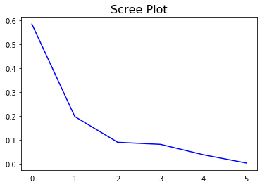

```python
plt.title('Scree Plot', fontsize=16)
plt.plot(var_contri, c='blue')
plt.show();
```

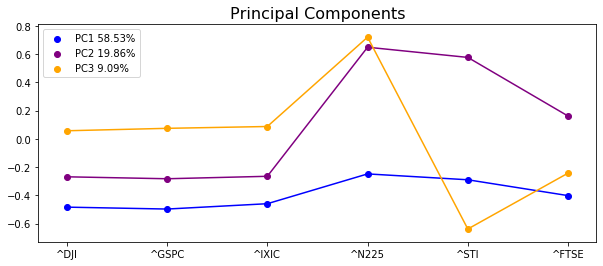

```python
fig = plt.figure(figsize=(10,4))
plt.title('Principal Components', fontsize=16)
colors = ['blue', 'purple', 'orange']
num = 3
for i in range(3):
    plt.plot(eigvecs[:,i], c=colors[i])
    plt.scatter(returns.columns, eigvecs[:,i], c=colors[i], label='PC{} {:.2f}%'.format(i+1, var_contri[i]*100))
plt.legend()
plt.show();
```

#### Monte Carlo Simulations

```python
L = np.linalg.cholesky(returns.cov()) # Cholesky Decomposition of Covariance Matrix
```

```python
portfolios = np.array([eigvecs[:,i]/eigvecs[:,i].sum() for i in range(len(eigvals))])
```

```python
n_sims = 10000
z = np.random.randn(n_sims, 252, len(L))
x = z @ L.T + returns.mean().values
sim_rets = ((x+1).prod(axis=1)-1) @ portfolios.T
```

```python
for i in range(len(portfolios)):
    print(f'Portfolio {i+1}')
    print('Mean Returns: {:.2f}% | Volatility: {:.2f}%'.format(sim_rets[:,i].mean()*100, sim_rets[:,i].std()*100))
```

```
Portfolio 1
Mean Returns: 12.45% | Volatility: 19.57%
Portfolio 2
Mean Returns: -5.81% | Volatility: 50.45%
Portfolio 3
Mean Returns: -25.02% | Volatility: 359.57%
Portfolio 4
Mean Returns: 92.96% | Volatility: 355.04%
Portfolio 5
Mean Returns: 97.80% | Volatility: 341.34%
Portfolio 6
Mean Returns: 61.12% | Volatility: 131.29%
```

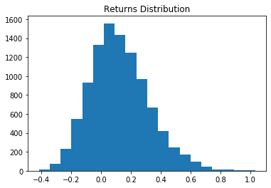

```python
plt.title('Returns Distribution') # Returns Distribution of Portfolio 1
plt.hist(sim_rets[:,0], bins=20)
plt.show();
```

```python
VAR = np.quantile(sim_rets[:,0], 0.05)
print('{:.2f}%'.format(VAR*100)) # Value at Risk % - 5% Chance to Lose More than:
```

```
-16.90%
```

```python
CVAR = sim_rets[:,0][sim_rets[:,0] < VAR].mean()
print('{:.2f}%'.format(CVAR*100)) # Conditional Value at Risk % - 5% to Lose:
```

```
-22.49%
```

Previous: Next:

Introduction to Machine Learning Intuition for Machine Learning (Part 2)